# Gene expression and Disease

Stephan Peischl

2024-05-17

# Introduction

In this analysis, we simulate a biological dataset where gene expression levels influence the presence or absence of a disease trait. We generate synthetic gene expression data, create a response variable (`disease_presence`), and fit logistic regression and decision tree models. Finally, we evaluate and visualize the models.

# Summary of the Script

## Dataset Generation:

- Number of Samples (n): 200
- Number of Features (p): 10 genes (named Gene1 to Gene10)
- Gene Expression Data: Simulated as normally distributed random values.
- Causal Genes:
  - Gene1: Positive effect with a coefficient of 0.5, plus interaction with Gene3.
  - Gene3: Positive effect with a coefficient of 0.8, plus interaction with Gene1.
  - Gene4: Negative effect with a coefficient of -0.3.
- Response Variable (disease_presence): Binary (indicating the presence or absence of a disease trait) generated based on a linear combination of Gene1, Gene3, and Gene4 with some added noise.

## Modeling:

- Logistic Regression: A generalized linear model (glm) with a binomial family was used to model the binary response variable (disease_presence).
- Decision Tree (rpart): A recursive partitioning tree was used to classify the binary response variable.

## Visualization:

# Data Generation

We simulate gene expression data for 200 samples and 10 genes. `Gene1`, `Gene3`, and `Gene4` are causal genes influencing disease presence.

```r
# Load required libraries
library(caret)
library(rpart)
library(ggplot2)
library(GGally)

# Set seed for reproducibility
set.seed(123)

# Number of samples
n <- 200

# Number of genes (features)
p <- 10

# Generate gene names
gene_names <- paste0("Gene", 1:p)

# Generate gene expression levels
genes_data <- data.frame(matrix(rnorm(n * p), nrow = n))
colnames(genes_data) <- gene_names

# True coefficients representing gene influence on disease presence
true_coefficients <- c(0.5, rep(0, 1), 0.8, -0.3, rep(0, p - 3))

# Generate disease trait presence based on gene expression levels
disease_presence <- ifelse(0.5 * genes_data$Gene1 + 0.8 * genes_data$Gene3 - 0.3 * genes_data$Gene4 - genes_data$Gene1*genes_data$Gene3 * 2 + rnorm(n, sd=0.5) > 0, 1, 0)

# Convert disease_presence to a factor with consistent levels
disease_presence <- factor(disease_presence, levels = c(0, 1), labels = c("Absent", "Present"))

# Combine gene expression and disease presence into a single data frame
bio_data <- data.frame(genes_data, disease_presence)
```

## Visualizations

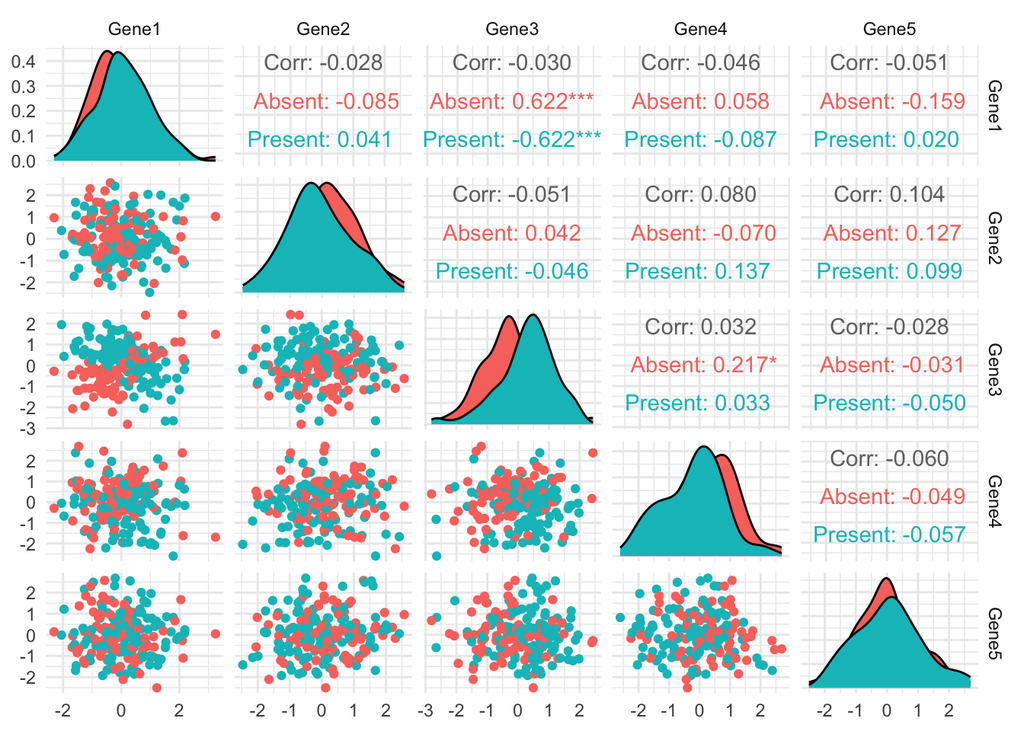

```r
# Pair Plot of some features colored by disease presence
pair_plot <- ggpairs(bio_data, columns = 1:5, aes(color = disease_presence)) +
  theme_minimal()
print(pair_plot)
```

## Modeling

We fit logistic regression and decision tree models to classify disease presence.

```r
# Using logistic regression
logistic_model <- glm(disease_presence ~ ., data = bio_data, family = "binomial")

# Using rpart for classification
rpart_model <- rpart(disease_presence ~ ., data = bio_data, method = "class")
```

## Evaluation

We evaluate and compare the accuracy of logistic regression and decision tree models.

```r
# Predictions from models
logistic_pred <- predict(logistic_model, type = "response")
rpart_pred <- predict(rpart_model, type = "class", newdata = bio_data)

# Convert predictions to factors with levels
logistic_pred <- factor(ifelse(logistic_pred > 0.5, "Present", "Absent"), levels = c("Absent", "Present"))
rpart_pred <- factor(rpart_pred, levels = levels(disease_presence))

# Evaluate model performance
logistic_accuracy <- confusionMatrix(logistic_pred, bio_data$disease_presence)$overall["Accuracy"]
rpart_accuracy <- confusionMatrix(rpart_pred, bio_data$disease_presence)$overall["Accuracy"]

# Display accuracy
cat("Logistic Regression Accuracy:", logistic_accuracy, "\n")
```

```
## Logistic Regression Accuracy: 0.74
```

```r
cat("Decision Tree (rpart) Accuracy:", rpart_accuracy, "\n")
```

```
## Decision Tree (rpart) Accuracy: 0.905
```

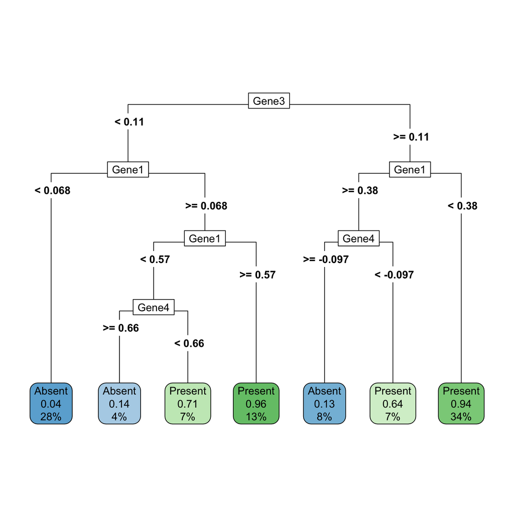

```r
# Plotting the decision tree
library(rpart.plot)
rpart.plot(rpart_model,type=5)
```

## Summarize Logistic Regression Coefficients

```r
# Summarizing logistic regression coefficients
summary(logistic_model)
```

```
##
## Call:
## glm(formula = disease_presence ~ ., family = "binomial", data = bio_data)
##
## Deviance Residuals:
##     Min       1Q   Median       3Q      Max
## -2.6003  -0.9978   0.5167   0.9085   1.9909
##
## Coefficients:
##             Estimate Std. Error z value Pr(>|z|)
## (Intercept)  0.31891    0.16361   1.949 0.051277 .
## Gene1        0.26941    0.17722   1.520 0.128464
## Gene2       -0.24082    0.16551  -1.455 0.145672
## Gene3        0.82736    0.18946   4.367 1.26e-05 ***
## Gene4       -0.57850    0.17151  -3.373 0.000744 ***
## Gene5        0.10475    0.16203   0.646 0.517959
## Gene6        0.10762    0.16665   0.646 0.518408
## Gene7        0.12048    0.17324   0.695 0.486788
## Gene8        0.39470    0.18067   2.185 0.028912 *
## Gene9       -0.12785    0.15425  -0.829 0.407174
## Gene10      -0.07877    0.15804  -0.498 0.618189
## ---
## Signif. codes:  0 '***' 0.001 '**' 0.01 '*' 0.05 '.' 0.1 ' ' 1
##
## (Dispersion parameter for binomial family taken to be 1)
##
##     Null deviance: 273.33  on 199  degrees of freedom
## Residual deviance: 227.19  on 189  degrees of freedom
## AIC: 249.19
##
## Number of Fisher Scoring iterations: 4
```

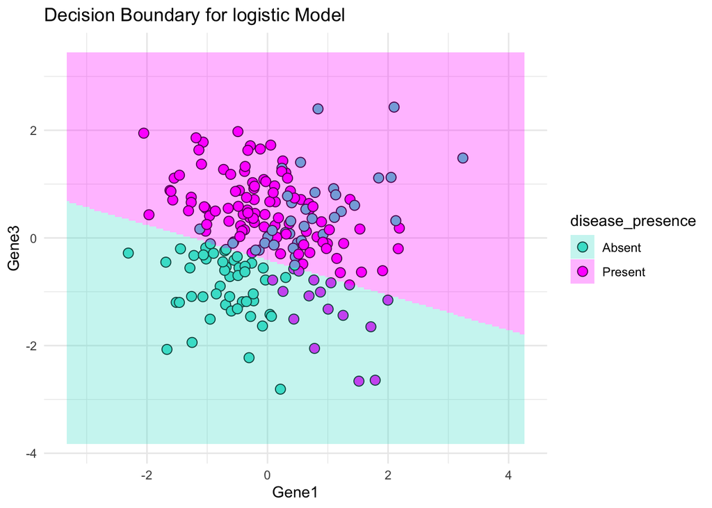

```r
# Decision boundary visualization
plot_decision_boundary <- function(model, data, feature1, feature2, model_type) {
  # Create grid for visualization
  grid <- expand.grid(
    Feature1 = seq(min(data[[feature1]]) - 1, max(data[[feature1]]) + 1, length.out = 200),
    Feature2 = seq(min(data[[feature2]]) - 1, max(data[[feature2]]) + 1, length.out = 200)
  )

  colnames(grid) <- c(feature1, feature2)

  # Add the remaining variables as means
  for (feature in setdiff(names(data), c(feature1, feature2, "disease_presence"))) {
    grid[[feature]] <- mean(data[[feature]])
  }

  if (model_type == "logistic") {
    grid$response <- predict(model, newdata = grid, type = "response")
    grid$response <- factor(ifelse(grid$response > 0.5, "Present", "Absent"), levels = c("Absent", "Present"))
  } else {
    grid$response <- predict(model, newdata = grid, type = "class")
  }

  ggplot(data, aes_string(x = feature1, y = feature2)) +
    geom_point(aes(fill=disease_presence),alpha = 1,shape = 21,col="black",size = 3) +
    geom_tile(data = grid, aes_string(fill = "response"), alpha = 0.3) +
    scale_fill_manual(values = c("Absent" = "turquoise", "Present" = "magenta")) +
        scale_color_manual(values = c("Absent" = "turquoise", "Present" = "magenta")) +
    theme_minimal() +
    labs(title = paste("Decision Boundary for", model_type, "Model"), x = feature1, y = feature2)
}



# Decision boundary for Logistic Regression using Gene1 and Gene3
print(plot_decision_boundary(logistic_model, bio_data, "Gene1", "Gene3", "logistic"))
```

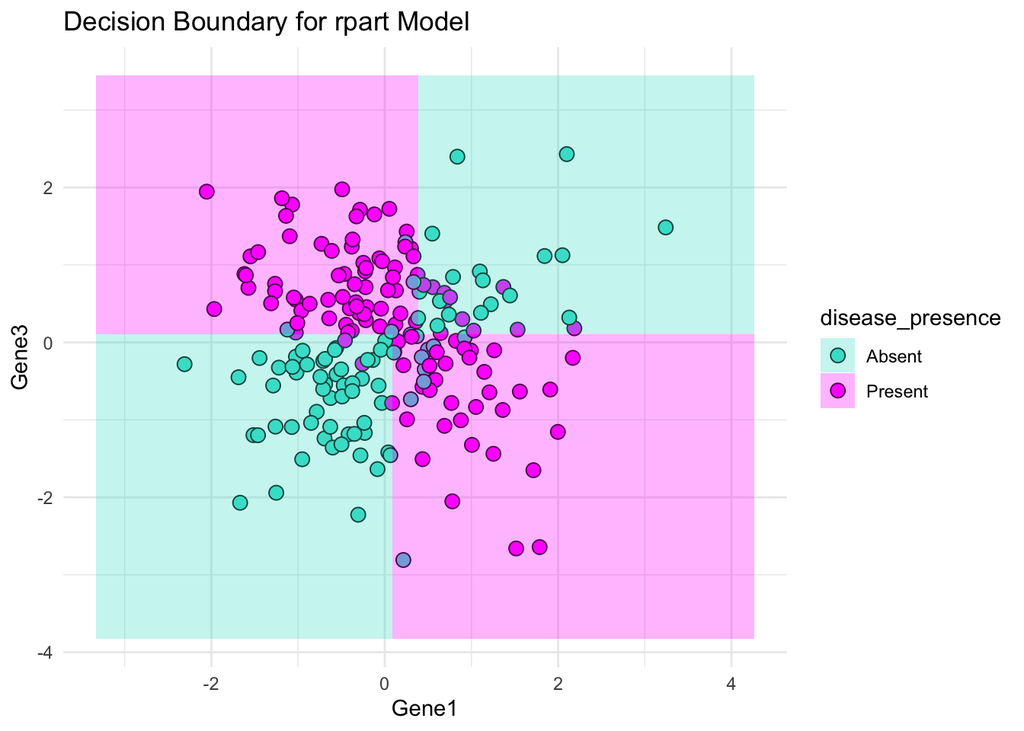

```r
# Decision boundary for rpart using Gene1 and Gene3
print(plot_decision_boundary(rpart_model, bio_data, "Gene1", "Gene3", "rpart"))
```